# Egyszempontos varianciaelemzés

# Példa. Arcok kitakarása és az emlékezet.

> Bizonyos bűncselekmények esetén egyre gyakoribb az áldozatok arcának kitakarása a tanúvallomások során. A televíziós közvetítések elszaporodása miatt, ez egyre nagyobb jelentőségű. Megfigyelték, hogy a kitakarás módja hatással lehet az esküdtek véleményére, nevezetesen, hogy mennyire gondolják hitelesnek a tanúvallomást. Egy vizsgálatban 4 különböző módszerrel fedtek el arcokat (nem volt elfedés, szürke folttal fedték el az arcot részlegesen, kipixelezték az arcot, negatív képet mutattak). A függő változó a vallomásokból származó tények százalékos aránya volt, amelyre a résztvevők helyesen emlékeztek. A hipotézis szerint az arc elfedése negatív hatással is lehet az emlékezetre, vagyis a résztvevők emlékezetét az áldozatok tanúvallomására befolyásolta a bemutatás feltétele: míg az arc negatív képének bemutatása nem csökkentette a emlékezetet a fedetlen állapothoz képest, a szürke folttal való maszkolás és a pixelezés azonban egyaránt rontotta az emlékezetet. Az adatokat a `kitakaras_emlekezet.sav` állományban találjuk. Vizsgáljuk meg, hogy a bemutatás (az arcok elfedésének módja) hatással van az emlékezetre (tények százalékos aránya, amelyre helyesen emlékeztek). Forrás: Brace, Snelgar, and Kemp (2016), 198-199. o.

## Beolvasás

```r
library(rio)
# install.packages('rio')
d <- import(file = "adatok/kitakaras_emlekezet.sav")
dim(d)
```

```
#> [1] 40  2
```

```r
names(d)
```

```
#> [1] "prescond" "memory"
```

```r
class(d$prescond)
```

```
#> [1] "numeric"
```

```r
class(d$memory)
```

```
#> [1] "numeric"
```

## Előkészítés

```r
# numerikusból faktor átalakítás
d$prescond <- factor(d$prescond)
levels(d$prescond) <- c("fedetlen", "szürke folt", "pixeles", "negatív")
```

## Leíró statisztika, mutatók

```r
library(psych)
describeBy(x = d$memory, group = d$prescond, mat = T, digits = 2)
```

```
#>     item      group1 vars  n mean   sd median trimmed  mad min max range  skew
#> X11    1    fedetlen    1 10 66.7 5.33   67.0   66.75 3.71  58  75    17 -0.23
#> X12    2 szürke folt    1 10 55.7 3.80   56.5   56.00 3.71  48  61    13 -0.56
#> X13    3     pixeles    1 10 57.7 5.42   57.0   57.25 6.67  51  68    17  0.45
#> X14    4     negatív    1 10 67.2 4.59   67.5   67.50 3.71  58  74    16 -0.43
#>     kurtosis   se
#> X11    -1.15 1.69
#> X12    -0.76 1.20
#> X13    -1.14 1.71
#> X14    -0.69 1.45
```

## Leíró statisztika, ábra

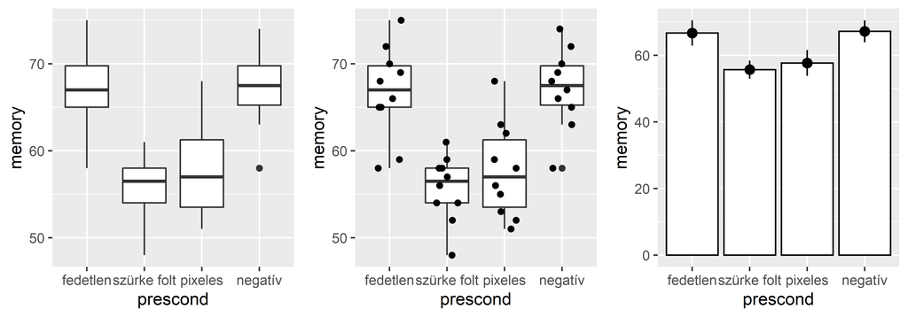

```r
library(ggplot2)
library(gridExtra)
p1 <- ggplot(data = d, aes(x = prescond, y = memory)) + geom_boxplot()
p2 <- ggplot(data = d, aes(x = prescond, y = memory)) + geom_boxplot() + geom_jitter(height = 0,
    width = 0.2)
p3 <- ggplot(data = d, aes(x = prescond, y = memory)) + stat_summary(fun.y = mean,
    geom = "bar", fill = "white", colour = "black") + stat_summary(fun.data = mean_cl_normal,
    geom = "pointrange")
grid.arrange(p1, p2, p3, nrow = 1)
```

## Előfeltétel vizsgálata

```r
library(DescTools)
LeveneTest(memory ~ prescond, data = d, center = "mean")  # Levene-próba
```

```
#> Levene's Test for Homogeneity of Variance (center = "mean")
#>       Df F value Pr(>F)
#> group  3  0.4895 0.6918
#>       36
```

```r
LeveneTest(memory ~ prescond, data = d, center = "median")  # Brown-Forsythe-próba a varianciákra
```

```
#> Levene's Test for Homogeneity of Variance (center = "median")
#>       Df F value Pr(>F)
#> group  3  0.4985 0.6857
#>       36
```

```r
by(data = d$memory, INDICES = d$prescond, shapiro.test)  # normalitásvizsgálat
```

```
#> d$prescond: fedetlen
#>
#>  Shapiro-Wilk normality test
#>
#> data:  dd[x, ]
#> W = 0.95915, p-value = 0.7761
#>
#> ------------------------------------------------------------
#> d$prescond: szürke folt
#>
#>  Shapiro-Wilk normality test
#>
#> data:  dd[x, ]
#> W = 0.95555, p-value = 0.7341
#>
#> ------------------------------------------------------------
#> d$prescond: pixeles
#>
#>  Shapiro-Wilk normality test
#>
#> data:  dd[x, ]
#> W = 0.95392, p-value = 0.7149
#>
#> ------------------------------------------------------------
#> d$prescond: negatív
#>
#>  Shapiro-Wilk normality test
#>
#> data:  dd[x, ]
#> W = 0.97845, p-value = 0.9563
```

## Próba végrehajtása

```r
d.aov <- aov(memory ~ prescond, data = d)  # egyszempontos varianciaelemzés
summary(d.aov)
```

```
#>             Df Sum Sq Mean Sq F value     Pr(>F)
#> prescond     3 1071.9   357.3   15.31 0.00000139 ***
#> Residuals   36  839.9    23.3
#> ---
#> Signif. codes:  0 '***' 0.001 '**' 0.01 '*' 0.05 '.' 0.1 ' ' 1
```

```r
library(DescTools)
EtaSq(d.aov)  # a hatás nagysága
```

```
#>             eta.sq eta.sq.part
#> prescond 0.5606701   0.5606701
```

```r
# utóvizsgálat
pairwise.t.test(x = d$memory, g = d$prescond, p.adjust.method = "bonf", pool.sd = T)  # egyenlő varianciák
```

```
#>
#>  Pairwise comparisons using t tests with pooled SD
#>
#> data:  d$memory and d$prescond
#>
#>             fedetlen szürke folt pixeles
#> szürke folt 0.000068 -           -
#> pixeles     0.00111  1.00000     -
#> negatív     1.00000  0.000033    0.00056
#>
#> P value adjustment method: bonferroni
```

```r
pairwise.t.test(x = d$memory, g = d$prescond, p.adjust.method = "bonf", pool.sd = F)  # nem egyenlő varianciák
```

```
#>
#>  Pairwise comparisons using t tests with non-pooled SD
#>
#> data:  d$memory and d$prescond
#>
#>             fedetlen szürke folt pixeles
#> szürke folt 0.0004   -           -
#> pixeles     0.0089   1.0000      -
#> negatív     1.0000   0.000064    0.0032
#>
#> P value adjustment method: bonferroni
```

```r
# normalitásvizsgálat a reziduumra
aov.residuals <- residuals(object = d.aov)
shapiro.test(x = aov.residuals)
```

```
#>
#>  Shapiro-Wilk normality test
#>
#> data:  aov.residuals
#> W = 0.98445, p-value = 0.8473
```

## Szöveges értékelés

Az egyszempontos varianciaelemzés eredménye alapján azt mondhatjuk, elegendő bizonyítékunk van arra, hogy a résztvevők emlékezetét a tanúvallomások tényeire szignifikánsan meghatározza a bemutatás feltétele ($F(3,36)=15,31;p<0,001, \eta^2=0,56$). Az utóelemzés minden pár esetében szignifikáns különbséget mutatott ki ($p \leq 0,001$), kivéve fedetlen-negatív pár ($p=1$) és a pixeles-szürke folt pár ($p=1$) esetében.

## Alternatívák

```r
oneway.test(memory ~ prescond, data = d)  # Welch-féle egyszempontos varianciaelemzés
```

```
#>
#>  One-way analysis of means (not assuming equal variances)
#>
#> data:  memory and prescond
#> F = 16.488, num df = 3.000, denom df = 19.797, p-value = 0.0000131
```

```r
library(onewaytests)  # Brown-Forsythe-próba a várható értékekre
bf.test(memory ~ prescond, data = d)
```

```
#>
#>   Brown-Forsythe Test (alpha = 0.05)
#> -------------------------------------------------------------
#>   data : memory and prescond
#>
#>   statistic  : 15.31432
#>   num df     : 3
#>   denom df   : 33.73297
#>   p.value    : 0.000001856768
#>
#>   Result     : Difference is statistically significant.
#> -------------------------------------------------------------
```

```r
# egyszempontos varianciaelemzés a onewaytests csomaggal, utóelemzéssel
d.aov.2 <- aov.test(memory ~ prescond, data = d)
```

```
#>
#>   One-Way Analysis of Variance (alpha = 0.05)
#> -------------------------------------------------------------
#>   data : memory and prescond
#>
#>   statistic  : 15.31432
#>   num df     : 3
#>   denom df   : 36
#>   p.value    : 0.0000013876
#>
#>   Result     : Difference is statistically significant.
#> -------------------------------------------------------------
```

```r
paircomp(d.aov.2, adjust.method = "bonferroni")
```

```
#>
#>   Bonferroni Correction (alpha = 0.05)
#> -----------------------------------------------------
#>     Level (a)   Level (b)       p.value   No difference
#> 1    fedetlen szürke folt 0.00028609049          Reject
#> 2    fedetlen     pixeles 0.00892383338          Reject
#> 3    fedetlen     negatív 1.00000000000      Not reject
#> 4 szürke folt     pixeles 1.00000000000      Not reject
#> 5 szürke folt     negatív 0.00005494734          Reject
#> 6     pixeles     negatív 0.00301333258          Reject
#> -----------------------------------------------------
```

```r
# normalitásvizsgálat onewaytests csomaggal
nor.test(memory ~ prescond, data = d)
```

```
#>
#>   Shapiro-Wilk Normality Test (alpha = 0.05)
#> --------------------------------------------------
#>   data : memory and prescond
#>
#>         Level Statistic   p.value   Normality
#> 1    fedetlen 0.9591491 0.7761280  Not reject
#> 2 szürke folt 0.9555454 0.7341324  Not reject
#> 3     pixeles 0.9539188 0.7149296  Not reject
#> 4     negatív 0.9784521 0.9563482  Not reject
#> --------------------------------------------------
```

```r
# Kruskal-Wallis-próba a onewaytests csomaggal, utóelemzéssel
d.aov.2 <- kw.test(memory ~ prescond, data = d)
```

```
#>
#>   Kruskal-Wallis Test (alpha = 0.05)
#> -------------------------------------------------------------
#>   data : memory and prescond
#>
#>   statistic  : 21.96449
#>   parameter  : 3
#>   p.value    : 0.0000663503
#>
#>   Result     : Difference is statistically significant.
#> -------------------------------------------------------------
```

```r
paircomp(d.aov.2)
```

```
#>
#>   Bonferroni Correction (alpha = 0.05)
#> -----------------------------------------------------
#>     Level (a)   Level (b)     p.value   No difference
#> 1    fedetlen szürke folt 0.003381457          Reject
#> 2    fedetlen     pixeles 0.021360962          Reject
#> 3    fedetlen     negatív 1.000000000      Not reject
#> 4 szürke folt     pixeles 1.000000000      Not reject
#> 5 szürke folt     negatív 0.002228832          Reject
#> 6     pixeles     negatív 0.013061470          Reject
#> -----------------------------------------------------
```

[figure not shown]

# Irodalom

Brace, Nicola, Rosemary Snelgar, and Richard Kemp. 2016. *SPSS for Psychologists: And Everybody Else*. Red Globe Press.